# Introduction: Mind Over Data

Fernando Miguez

1/11/2021

# Fertilizer Example

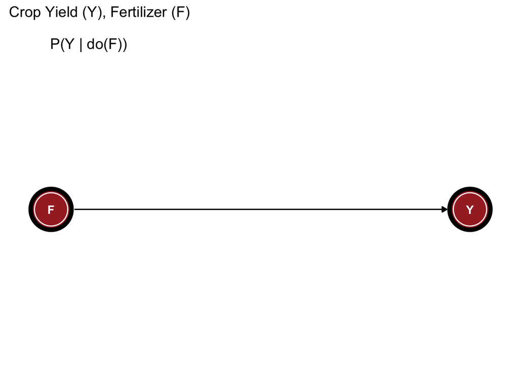

## Experiments

Observational effects are not identical to experimental manipulations

(Review text on page 8)

$$P(Y | F) \neq P(Y | do(F))$$

# Plant Growth Example

We know that plant growth is a result of photosynthesis, therefore it responds to solar radiation, but when we simply observe this in the real world, we might notice that it is confounded with the effect of temperature as more solar radiation is normally associated with higher temperatures.

How can we separate the individual effects of these two variables? We could perform an experiment in which we manipulate both solar radiation and temperature individually in a growth chamber. We could also use lots and lots of data and then build a statistical model, which we can further query for these specific effects.

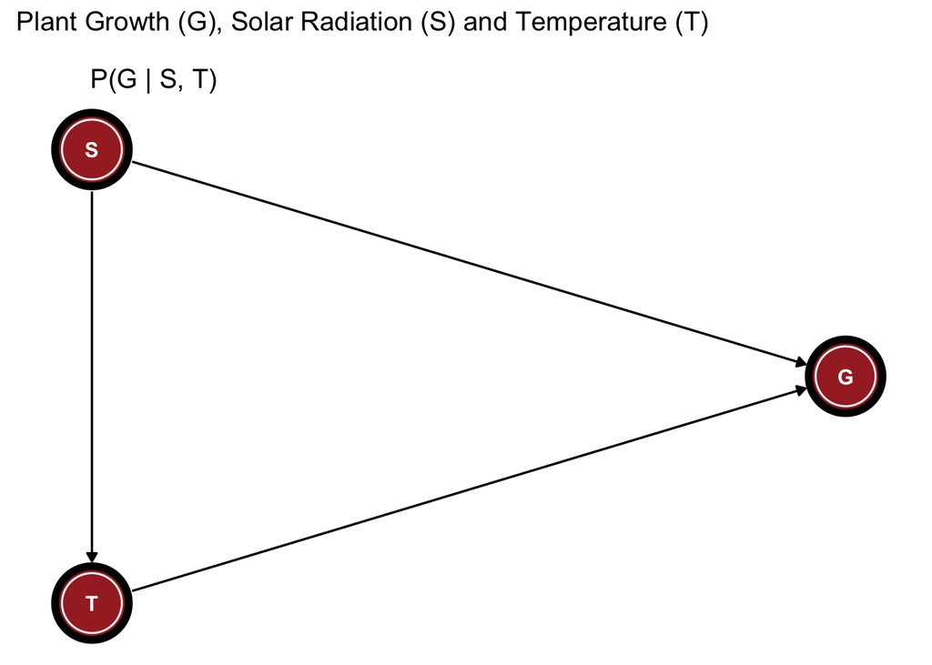

The *do* operator represents an intervention, which as a result erases the arrow from solar radiation to temperature.

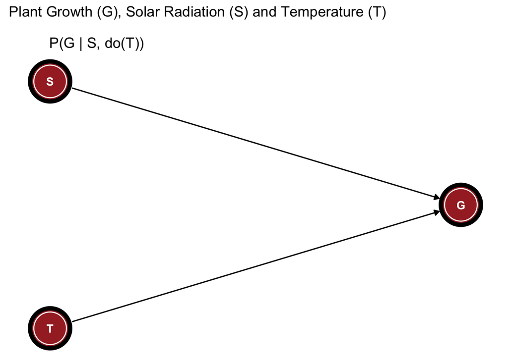

# Notable quotes

> Data are profoundly dumb

> That’s all that a deep-learning program can do: fit a function to data

> Data do not understand cause and effects; humans do

## Calculus of Causation

1. Causal Diagrams (commonly DAGS)
2. Symbolic language (math)

Causal diagrams are fundamental to understanding the “data generating process” or the “cause and effect” forces behind the data.

# Inference Engine

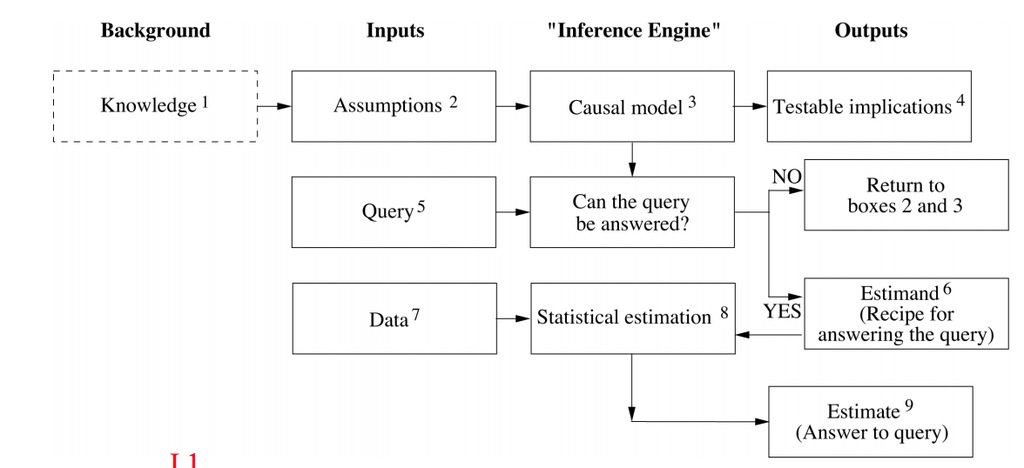

Inference-Engine